# Porządkowanie liniowe i analiza skupień

Filip Kopańko

2023-12-17

# 1. Opis danych

```r
library(readxl)
# Wczytanie danych z pliku Excel
data <- read_excel("C:\\Users\\MiroT\\Downloads\\caffeine.xlsx")
data
```

| drink | Volume (ml) | Calories | Caffeine (mg) | type |
| --- | --- | --- | --- | --- |
| Costa Coffee | 256.993715 | 0 | 277 | Coffee |
| Coffee Friend Brewed Coffee | 250.191810 | 0 | 145 | Coffee |
| Hell Energy Coffee | 250.191810 | 150 | 100 | Coffee |
| Killer Coffee (AU) | 250.191810 | 0 | 430 | Coffee |
| Nescafe Gold | 250.191810 | 0 | 66 | Coffee |
| Espresso Monster | 248.417400 | 170 | 160 | Coffee |
| Dunkin Donuts Shot In The Dark | 239.545350 | 80 | 134 | Coffee |
| Illy Issimo Cafe | 201.099800 | 45 | 155 | Coffee |
| Starbucks Doubleshot Espresso | 192.227750 | 140 | 120 | Coffee |
| TrueStart Performance Coffee | 150.824850 | 0 | 95 | Coffee |

[output cut: 600 more lines]

Analiza została przeprowadzona na podstawie danych pozyskanych ze strony internetowej [kaggle.com](https://www.kaggle.com/datasets/heitornunes/caffeine-content-of-drinks). Dane przedstawiają listę napojów zawierających kofeinę. Niektóre obserwacje nie są dosłownie napojami, a dokładnie mielona kawa lub liście herbaty, które wyprodukowałyby taką objętość (ml), jeśli zostałyby przygotowane zgodnie z zaleceniami producenta.

Atrybuty:

- drink - nazwa napoju
- Volume (ml) - objętość
- Calories - Ilość kalorii
- Caffeine (mg) - Ilość kofeiny
- type - typ napoju (Coffee, Energy Drinks, Energy Shots, Soft Drinks, Tea, Water)

# 2. Wstępna analiza danych

#### Statystyki opisowe:

```r
summary(data[, c(2, 3, 4)])
```

```
##   Volume (ml)          Calories      Caffeine (mg)
##  Min.   :   7.393   Min.   :  0.00   Min.   :   0.0
##  1st Qu.: 236.588   1st Qu.:  0.00   1st Qu.:  50.0
##  Median : 354.882   Median : 25.00   Median : 100.0
##  Mean   : 346.544   Mean   : 75.53   Mean   : 134.7
##  3rd Qu.: 473.176   3rd Qu.:140.00   3rd Qu.: 160.0
##  Max.   :1419.528   Max.   :830.00   Max.   :1555.0
```

#### Macierz korelacji:

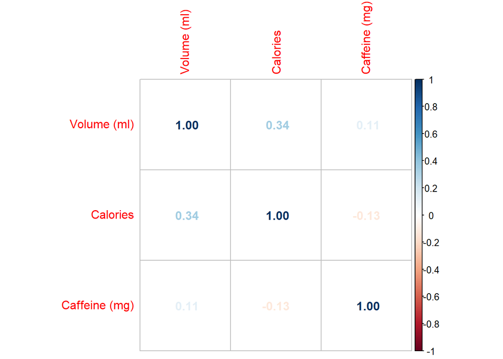

```r
library(corrplot)
cor_matrix <- cor(data[, c(2, 3, 4)])
corrplot(cor_matrix, method = "number")
```

Wszędzie |corr|< 0.9, nie ma więc powodu do odrzucenia zmiennych do analizy skupień.

#### Współczynnniki zmiennośći:

```r
coefficient_of_variation<- function(x) {
  cv <- sd(x) / abs(mean(x))
  return(cv)
}
cvs <- sapply(data[, c(2, 3, 4)], coefficient_of_variation)
cvs
```

```
##   Volume (ml)      Calories Caffeine (mg)
##     0.4148042     1.2551648     1.1534553
```

Wszędzie współczynnik zmienności jest większy od 10%, więc nie ma konieczności odrzucenia zmiennych do analizy skupień.

#### Wykresy:

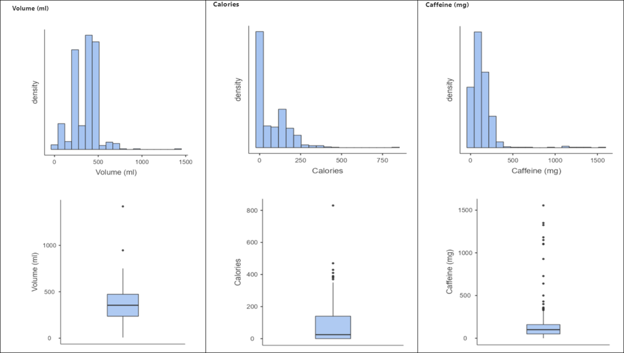

# 3. Porządkowanie liniowe

## Metoda Hellwiga

Załóżmy, że dla kogoś, kto sięga po napój zawierający kofeinę, najbardziej pożądany jest napój z jej największą ilością, jednocześnie zawierający jak najmniej kalorii. Możemy więc zauważyć, że zmienna ‘Caffeine (mg)’ jest stymulantą, ‘Calories’ jest destymulantą, a zmienną ‘Volume (ml)’ możemy traktować jako nominantę (idealny napój ma 250ml). Spróbujemy odpowiedzieć sobie na pytanie, jaki napój jest najlepszy pod względem przyjętych kryteriów.

W pierwszej kolejności należy wszystkie cechy zamienić na stymulanty. Dla zmiennej ‘Calories’ uzyskamy to mnożąc wartości zmiennej przez (-1), natomiast dla ‘Volume (ml)’ skorzystamy ze wzoru:

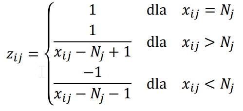

Gdzie Nj oznacza wartość nominalną dla j-tej zmiennej (tj. wartość optymalna, najlepsza).

```r
data2 <- data.frame(data)
data2[,3] <- data2[,3]* (-1)
data2[,2] <- ifelse(data2[,2] == 250,1,
              ifelse(data2[,2] < 250, -1/(data2[,2]-250-1),1/(data2[,2]-250+1)))
data2
```

| drink | Volume..ml. | Calories | Caffeine..mg. | type |
| --- | --- | --- | --- | --- |
| Costa Coffee | 0.1250982803 | 0 | 277 | Coffee |
| Coffee Friend Brewed Coffee | 0.8390599173 | 0 | 145 | Coffee |
| Hell Energy Coffee | 0.8390599173 | -150 | 100 | Coffee |
| Killer Coffee (AU) | 0.8390599173 | 0 | 430 | Coffee |
| Nescafe Gold | 0.8390599173 | 0 | 66 | Coffee |
| Espresso Monster | 0.3872066909 | -170 | 160 | Coffee |
| Dunkin Donuts Shot In The Dark | 0.0873007905 | -80 | 134 | Coffee |
| Illy Issimo Cafe | 0.0200399998 | -45 | 155 | Coffee |
| Starbucks Doubleshot Espresso | 0.0170148327 | -140 | 120 | Coffee |
| TrueStart Performance Coffee | 0.0099825156 | 0 | 95 | Coffee |

[output cut: 600 more lines]

Następnie standaryzuje dane:

```r
  data_standardized <- data.frame(scale(data2[,2:4]))
  data_standardized
```

| Volume..ml. | Calories | Caffeine..mg. |
| --- | --- | --- |
| 0.23591342 | 0.79670816 | 0.915962519 |
| 3.68236410 | 0.79670816 | 0.066338617 |
| 3.68236410 | -0.78557167 | -0.223305895 |
| 3.68236410 | 0.79670816 | 1.900753860 |
| 3.68236410 | 0.79670816 | -0.442148415 |
| 1.50116867 | -0.99654232 | 0.162886788 |
| 0.05345657 | -0.04717442 | -0.004463374 |
| -0.27122613 | 0.32202421 | 0.130704064 |
| -0.28582929 | -0.68008635 | -0.094575000 |
| -0.31977583 | 0.79670816 | -0.255488618 |

[output cut: 600 more lines]

Tworzę wzorzec, tj. „najlepszy” obiekt:

```r
  pattern <- apply(data_standardized,2,max)
  pattern
```

```
##   Volume..ml.      Calories Caffeine..mg.
##     4.0048163     0.7967082     9.1418667
```

Obliczam odległość obiektów od wzorca (bez wag):

```r
  distance <- apply(data_standardized, 1,  function(row) {sqrt(sum((row-pattern)^2))})
  head(distance)
```

```
## [1] 9.048211 9.081255 9.503370 7.248289 9.589438 9.492422
```

Tworzę odległość „możliwie daleką”:

```r
  max_distance <- mean(distance) + 2*sd(distance)
  head(max_distance)
```

```
## [1] 11.80106
```

Znajduję wartość miary dla każdego obiektu:

```r
  result <- c(1 - distance/max_distance)
  head(result)
```

```
## [1] 0.2332712 0.2304712 0.1947019 0.3857933 0.1874086 0.1956296
```

```r
  rank_order2 <- data[order(-result), 1:5]
  rank_order2
```

| drink | Volume (ml) | Calories | Caffeine (mg) | type |
| --- | --- | --- | --- | --- |
| Black Label Brewed Coffee | 354.882000 | 0 | 1555 | Coffee |
| Very Strong Coffee | 354.882000 | 0 | 1350 | Coffee |
| Devils Brew Extreme Caffeine Coffee | 354.882000 | 0 | 1325 | Coffee |
| Taft Coffee (EU) | 354.882000 | 0 | 1182 | Coffee |
| High Voltage Coffee (AU) | 354.882000 | 0 | 1150 | Coffee |
| Black Insomnia Coffee | 354.882000 | 0 | 1105 | Coffee |
| Cannonball Coffee Maximum Charge (UK) | 354.882000 | 0 | 1101 | Coffee |
| Biohazard Coffee | 354.882000 | 3 | 928 | Coffee |
| Death Wish Coffee | 354.882000 | 0 | 728 | Coffee |
| Killer Coffee (AU) | 250.191810 | 0 | 430 | Coffee |

[output cut: 600 more lines]

### Wynik

Okazuje się, że najlepsza – pod względem użytych kryteriów – jest kawa “Black Label Brewed Coffee”. Najgorszym natomiast wyborem okazuje się również kawa - “Arby’s Jamocha Shake”

# 4. Analiza skupień

## Metoda k-średnich

Aby wyonać analizę skupień, pozwolę sobie wybrać próbę losową z danych.

```r
  set.seed(433)
  df <- sample(1:nrow(data), 50)
  sample <- data[df,]
  sample
```

| drink | Volume (ml) | Calories | Caffeine (mg) | type |
| --- | --- | --- | --- | --- |
| Peace Tea | 680.1905 | 150 | 23 | Tea |
| La Colombe Draft Latte | 266.1615 | 90 | 120 | Coffee |
| Big Train Spiced Chai | 236.5880 | 210 | 65 | Tea |
| Starbucks 2X Coffee Pods | 236.5880 | 0 | 260 | Coffee |
| Hype Energy Drink (EU) | 250.1918 | 108 | 80 | Energy Drinks |
| Pibb Xtra | 354.8820 | 140 | 40 | Soft Drinks |
| 3 Water | 499.7921 | 0 | 50 | Water |
| Monster Zero Sugar | 473.1760 | 10 | 140 | Energy Drinks |
| Alpine Start Instant Coffee | 236.5880 | 0 | 120 | Coffee |
| Strike Force Energy Drink Mix | 500.0879 | 0 | 160 | Energy Drinks |

[output cut: 40 more lines]

Ponieważ nie chcemy, aby algorytm grupowania był zależny od dowolnej jednostki zmiennej, zaczynamy od skalowania.

```r
  data_standardized2 <- scale(sample[,2:4])
  data_standardized2
```

```
##       Volume (ml)   Calories Caffeine (mg)
##  [1,]  2.24476289  0.9669953   -1.27154578
##  [2,] -0.67262450  0.2428351    0.01997192
##  [3,] -0.88100932  1.6911555   -0.71233193
##  [4,] -0.88100932 -0.8434053    1.88401809
##  [5,] -0.78515230  0.4600831   -0.51261269
##  [6,] -0.04747006  0.8463019   -1.04519731
##  [7,]  0.97361553 -0.8434053   -0.91205116
##  [8,]  0.78606920 -0.7227119    0.28626423
##  [9,] -0.88100932 -0.8434053    0.01997192
## [10,]  0.97569938 -0.8434053    0.55255654
## [11,] -0.46423969  0.4842218   -1.57778193
## [12,] -0.04747006 -0.4209785   -1.37806270
## [13,] -0.15166247 -0.4209785   -0.57918577
## [14,]  1.61960845 -0.8434053   -0.64575885
```

[output cut: 42 more lines]

Aby sprawdzić, czy w moich danych nie ma obiektów, które są outlierami, stosuję regułę trzech sigm.

```r
  sigm_3 <- apply(data_standardized2, MARGIN = c(1, 2), FUN = function(x) abs(x) > 3)
  sigm_3
```

```
##       Volume (ml) Calories Caffeine (mg)
##  [1,]       FALSE    FALSE         FALSE
##  [2,]       FALSE    FALSE         FALSE
##  [3,]       FALSE    FALSE         FALSE
##  [4,]       FALSE    FALSE         FALSE
##  [5,]       FALSE    FALSE         FALSE
##  [6,]       FALSE    FALSE         FALSE
##  [7,]       FALSE    FALSE         FALSE
##  [8,]       FALSE    FALSE         FALSE
##  [9,]       FALSE    FALSE         FALSE
## [10,]       FALSE    FALSE         FALSE
## [11,]       FALSE    FALSE         FALSE
## [12,]       FALSE    FALSE         FALSE
## [13,]       FALSE    FALSE         FALSE
## [14,]       FALSE    FALSE         FALSE
```

[output cut: 36 more lines]

Wszystkie obiekty przyjmują wartość “FALSE”, oznacza to, że w moich danych nie ma outlierów.

Następnie, aby wybrać optymalną liczbę grup, posłużę się metodą łokciową (elbow method), za pomocą której liczba grup dobierana jest tak, aby zminimalizować zmienność wewnątrz wszystkich klastrów.

```r
  library(psych)
  library(factoextra)
```

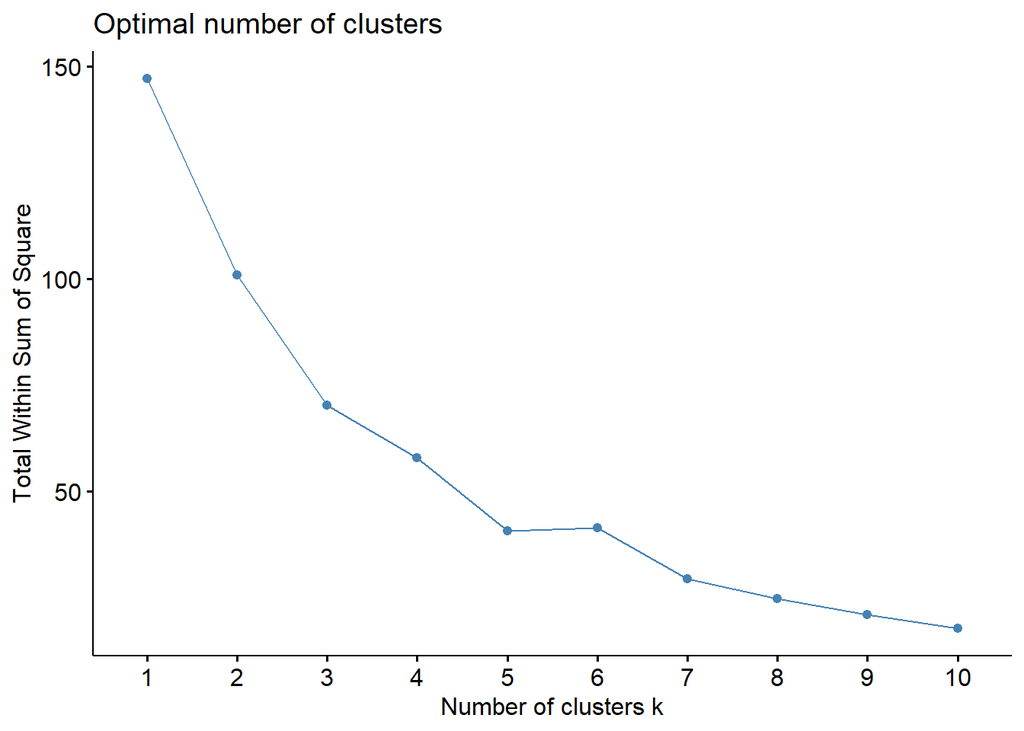

```r
  fviz_nbclust(data_standardized2, kmeans, method= "wss")
```

Poszukuję punktu, w którym tempo spadku wartości WSS zmniejsza się, a wykres zaczyna przybierać charakterystyczny kształt łokcia. W tym przypadku taka zmiana zachodzi między trzecią a czwartą liczbą grup, co sugeruje, że optymalną liczbą klastrów zgodnie z metodą WSS jest 3.

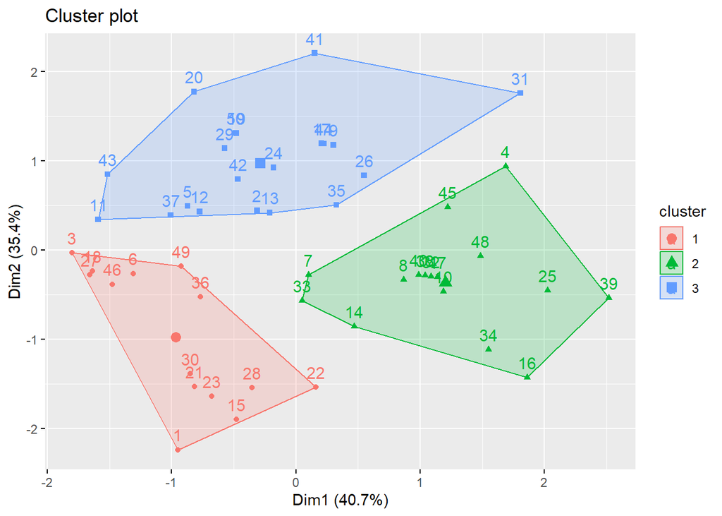

```r
  km <- kmeans(data_standardized2, 3, 100000)
  cluster <-fviz_cluster(km, sample[,2:4])
  cluster
```

```r
  wynik <- describeBy(sample[,2:4], group = km$cluster)
  wynik
```

```
##
##  Descriptive statistics by group
## group: 1
##               vars  n   mean     sd median trimmed   mad    min    max range
## Volume (ml)      1 14 411.62 104.42 380.02  403.83 84.18 236.59 680.19 443.6
## Calories         2 14 184.71  41.10 176.50  182.25 48.93 139.00 260.00 121.0
## Caffeine (mg)    3 14  97.71  70.20  92.50   94.42 90.44  10.00 225.00 215.0
##               skew kurtosis    se
## Volume (ml)   0.85     0.78 27.91
## Calories      0.44    -1.31 10.98
## Caffeine (mg) 0.27    -1.42 18.76
## ------------------------------------------------------------
## group: 2
##               vars  n   mean    sd median trimmed   mad    min    max  range
## Volume (ml)      1 16 476.34 97.57 473.18  481.01 39.46 236.59 650.62 414.03
## Calories         2 16   4.38 10.14   0.00    2.14  0.00   0.00  40.00  40.00
## Caffeine (mg)    3 16 169.50 68.73 160.00  168.71 59.30  50.00 300.00 250.00
##                skew kurtosis    se
## Volume (ml)   -0.61     0.53 24.39
## Calories       2.67     6.54  2.54
## Caffeine (mg)  0.00    -0.80 17.18
## ------------------------------------------------------------
## group: 3
##               vars  n   mean   sd median trimmed   mad   min    max  range
## Volume (ml)      1 20 234.84 84.4 236.59  241.80 32.01 59.15 354.88 295.74
## Calories         2 20  41.90 48.1  30.00   36.44 44.48  0.00 130.00 130.00
## Caffeine (mg)    3 20  92.25 64.9  82.50   84.69 51.89  0.00 300.00 300.00
##                skew kurtosis    se
## Volume (ml)   -0.75    -0.10 18.87
## Calories       0.61    -1.28 10.75
## Caffeine (mg)  1.45     2.77 14.51
```

**Grupa 1**: Są to napoje najgorsze pod względem przyjętych już wcześniej kryteriów. Zawierają najwięcej, ze wszystkich grup, kalori na 100ml, bo średnio aż 45, oraz najmniej kofeiny na 100ml, bo średnio niespełna 24mg.

**Grupa 2**: Są to dobre napoje pod względem przyjętych wcześniej kryteriów. Zawierają średnio 35mg kofeiny na 100ml, oraz najmniej kalori na 100ml, ze wszystkich grup, bo średnio poniżej 1 kalori.

**Grupa 3**: Są to napoje generalnie, w mojej ocenie, najlepsze. Są średnio najbardziej zbliżone objętością do przyjętej wcześniej idealnej objętości napoju. Zawierają najwięcej, ze wszystkich grup, kofeiny na 100ml, bo średnio ponad 39mg, jednak więcej kalori, niż w przypadku grupy 2, bo średnio prawie 18 kalori na 100ml.